# Model Planning and Building

Austin Meyer

3/12/2019

## Start with the past

Before we go forward with gathering more data we must first load what we did from the last part of our journey. You will not see this because I am hidding it from you, but if you test at home you will see it.

## Time to add more data

To start this part of my investigation I will be looking for another data set to supplement our previous data set. The catch to this one is that it will be from another source.Two parts of the data will be from Gallup. These two polls will help us figure out what people are thinking when choosing candidets. The other is from the NYTimes and gives us the results of the election so that we can reference it through out the report.

Before we go into our models we must first make functions to easily grab and sort our data.

```r
read_election_outcome <- function(url) {

  html_full <- read_html(url)

  outcome <- html_full %>% html_nodes("tbody")

  percent_won <-  outcome %>%
                  html_nodes("span.eln-percent") %>%
                  html_text()
  candid_name <- outcome %>%
                  html_nodes("span.eln-name") %>%
                  html_text()
  party <- outcome %>%
                  html_nodes("span.eln-party") %>%
                  html_text()

  results <- tibble( percent_won=percent_won, candidite_name=candid_name, party=party)
}

read_congress_approval <- function(url, div)
{
  html_full <- read_html(url)

  outcome <- html_full %>% html_node(div)
  tbody_data <- outcome %>% html_nodes("tbody")
  tr_data <- tbody_data %>% html_nodes("tr")

  poll_date <- tbody_data %>%
                html_nodes("th[scope=row]") %>%
                html_text()

  approve <- tbody_data %>%
                html_nodes("td[data-th='Yes, deserves']") %>%
                html_text()

  disapprove <- outcome %>%
                html_nodes("td[data-th='No, does not']") %>%
                html_text()

  no_opinion <- outcome %>%
                html_nodes("td[data-th='No opinion']") %>%
                html_text()

  results <- tibble(poll_date=poll_date, approve=approve, disapprove=disapprove, no_opinion=no_opinion)
}
```

After initializing our helpers we can now use them to gather our data from the websites as seen bellow.

```r
# Then using the funciton we made above, we will gather the data from the website.
election_result <- read_election_outcome(url = "https://www.nytimes.com/interactive/2018/11/06/us/elections/results-house-elections.html")
other_congress_feels <- read_congress_approval(url = "https://news.gallup.com/poll/1600/congress-public.aspx", div = "div#ite-235073")
your_congress_feels <- read_congress_approval(url = "https://news.gallup.com/poll/1600/congress-public.aspx", div = "div#ite-235070")
```

## Clean up

The only item that looks like it needs a good scrubing is the date. So we are going to turn it into POSIX standard time so that when we work with the data we will not get confused and it is all standardized. To make the dates simpler we are going to only record the date when the poll started polling.

```r
your_congress_feels$poll_date <- sub("-.*", "", your_congress_feels$poll_date)
other_congress_feels$poll_date <- sub("-.*", "", other_congress_feels$poll_date)

# Row 42 has an issue and doesn't follow the same format as the others.
# We are going to have to change it manually
other_congress_feels$poll_date[other_congress_feels$poll_date == "1992 Jul 31 Aug 2"] <- strtrim("1992 Jul 31 Aug 2", nchar("1992 Jul 31 Aug 2")-6)

your_congress_feels$poll_date <- as.POSIXlt(parse_datetime(your_congress_feels$poll_date, format="%Y %b %d", locale = locale("en")))
other_congress_feels$poll_date <- as.POSIXlt(parse_datetime(other_congress_feels$poll_date, format="%Y %b %d", locale = locale("en")))
```

Also found some areas were our data could be cleaned better. We should first turn the states and districts into factors.

```r
national_data$state <- as.factor(national_data$state)
national_data$district <- as.factor(national_data$district)
```

# Modeling data

Now that we have acquired our secondary data sources we must now seek out correlations in our data. To do this we will be using the lm function. This makes it easier for us to model data. We will only need the original data set to do this.I want to first model what corelations can be made with the win_probability and the other variables from the national_data set.

```r
national_model <- lm(national_data, formula=win_probability~state+district+party+incumbent)
summary(national_model)
```

```
##
## Call:
## lm(formula = win_probability ~ state + district + party + incumbent,
##     data = national_data)
##
## Residuals:
##      Min       1Q   Median       3Q      Max
## -0.90310 -0.13465 -0.01651  0.06972  0.89783
##
## Coefficients:
##                               Estimate Std. Error t value Pr(>|t|)
## (Intercept)                 -9.121e-02  1.291e-02  -7.064 1.62e-12 ***
## stateAL                      1.305e-03  1.042e-02   0.125 0.900328
## stateAR                      2.252e-02  1.048e-02   2.149 0.031655 *
## stateAZ                      8.731e-02  1.023e-02   8.535  < 2e-16 ***
## stateCA                      1.786e-02  9.918e-03   1.800 0.071790 .
## stateCO                      5.130e-02  1.037e-02   4.949 7.47e-07 ***
## stateCT                      7.372e-02  1.053e-02   7.000 2.56e-12 ***
## stateDE                      3.581e-13  1.360e-02   0.000 1.000000
## stateFL                      7.994e-02  9.954e-03   8.030 9.75e-16 ***
## stateGA                      8.967e-03  1.009e-02   0.888 0.374370
## stateHI                      1.924e-01  1.182e-02  16.274  < 2e-16 ***
## stateIA                      9.657e-03  1.069e-02   0.903 0.366413
## stateID                      1.924e-01  1.182e-02  16.274  < 2e-16 ***
## stateIL                      2.847e-02  9.989e-03   2.850 0.004366 **
## stateIN                      7.867e-02  1.021e-02   7.704 1.32e-14 ***
## stateKS                      9.229e-02  1.063e-02   8.686  < 2e-16 ***
## stateKY                      1.459e-02  1.035e-02   1.410 0.158660
## stateLA                     -5.283e-02  1.019e-02  -5.185 2.16e-07 ***
## stateMA                      1.206e-01  1.033e-02  11.677  < 2e-16 ***
## stateMD                      5.082e-02  1.017e-02   4.997 5.81e-07 ***
## stateME                      2.169e-02  1.144e-02   1.896 0.057940 .
## stateMI                      8.919e-02  1.008e-02   8.849  < 2e-16 ***
## stateMN                      1.427e-01  1.030e-02  13.856  < 2e-16 ***
## stateMO                      1.469e-02  1.016e-02   1.447 0.147959
## stateMS                      1.109e-01  1.079e-02  10.275  < 2e-16 ***
## stateMT                      1.866e-02  1.244e-02   1.500 0.133513
## stateNC                      4.200e-02  1.005e-02   4.177 2.95e-05 ***
## stateND                      2.904e-01  1.250e-02  23.229  < 2e-16 ***
## stateNE                      4.606e-03  1.117e-02   0.413 0.679926
```

[output cut: 87 more lines]

```
## partyR                       1.646e-01  8.637e-03  19.058  < 2e-16 ***
## partyREF                     7.370e-03  1.082e-02   0.681 0.495862
## partyReform Party            1.570e-02  1.638e-02   0.958 0.338055
## partyUS Taxpayers           -4.643e-03  1.197e-02  -0.388 0.698128
## partyWOF                    -7.612e-01  1.654e-02 -46.027  < 2e-16 ***
## partyWomen's Equality Party  3.767e-02  6.793e-02   0.555 0.579211
## partyWorking Class          -2.077e-02  1.330e-02  -1.562 0.118394
## incumbentTRUE                7.662e-01  9.704e-04 789.535  < 2e-16 ***
## ---
## Signif. codes:  0 '***' 0.001 '**' 0.01 '*' 0.05 '.' 0.1 ' ' 1
##
## Residual standard error: 0.2332 on 283478 degrees of freedom
##   (19257 observations deleted due to missingness)
## Multiple R-squared:  0.7364, Adjusted R-squared:  0.7363
## F-statistic:  6439 on 123 and 283478 DF,  p-value: < 2.2e-16
```

Now we want to see if the data we chose will be a good model to use in our analysis. To do this we will grab a random amount of data from the set and call it our trained set. This set will be used to see if it can predict the other 30% of the data we did not grab.

```r
set.seed(4567)

index <- createDataPartition(national_data$win_probability, p = 0.70, list=FALSE)

train <- national_data[index, ]
test <- national_data[-index, ]

train_model <- lm(train, formula=win_probability~state+district+party+incumbent)
summary(train_model)
```

```
##
## Call:
## lm(formula = win_probability ~ state + district + party + incumbent,
##     data = train)
##
## Residuals:
##      Min       1Q   Median       3Q      Max
## -0.91169 -0.13474 -0.01699  0.06939  0.89310
##
## Coefficients:
##                               Estimate Std. Error t value Pr(>|t|)
## (Intercept)                 -0.0907741  0.0152362  -5.958 2.56e-09 ***
## stateAL                     -0.0009029  0.0122557  -0.074 0.941270
## stateAR                      0.0214773  0.0123149   1.744 0.081158 .
## stateAZ                      0.0839017  0.0120222   6.979 2.98e-12 ***
## stateCA                      0.0163567  0.0116537   1.404 0.160449
## stateCO                      0.0467519  0.0122098   3.829 0.000129 ***
## stateCT                      0.0768343  0.0123868   6.203 5.55e-10 ***
## stateDE                      0.0010610  0.0162245   0.065 0.947861
## stateFL                      0.0784736  0.0116956   6.710 1.96e-11 ***
## stateGA                      0.0075590  0.0118626   0.637 0.523989
## stateHI                      0.1875256  0.0140356  13.361  < 2e-16 ***
## stateIA                      0.0139726  0.0126041   1.109 0.267613
## stateID                      0.1936409  0.0139212  13.910  < 2e-16 ***
## stateIL                      0.0269107  0.0117361   2.293 0.021849 *
## stateIN                      0.0805401  0.0120142   6.704 2.04e-11 ***
## stateKS                      0.0892677  0.0125012   7.141 9.31e-13 ***
## stateKY                      0.0163039  0.0121762   1.339 0.180575
## stateLA                     -0.0527720  0.0119860  -4.403 1.07e-05 ***
## stateMA                      0.1172277  0.0121593   9.641  < 2e-16 ***
## stateMD                      0.0488893  0.0119552   4.089 4.33e-05 ***
## stateME                      0.0194283  0.0134429   1.445 0.148390
## stateMI                      0.0886154  0.0118491   7.479 7.54e-14 ***
## stateMN                      0.1449526  0.0121086  11.971  < 2e-16 ***
## stateMO                      0.0150047  0.0119452   1.256 0.209073
## stateMS                      0.1176561  0.0127075   9.259  < 2e-16 ***
## stateMT                      0.0181739  0.0146642   1.239 0.215221
## stateNC                      0.0417020  0.0118246   3.527 0.000421 ***
## stateND                      0.2987505  0.0146462  20.398  < 2e-16 ***
## stateNE                      0.0023052  0.0131870   0.175 0.861230
```

[output cut: 87 more lines]

```
## partyR                       0.1651649  0.0102580  16.101  < 2e-16 ***
## partyREF                     0.0010915  0.0128675   0.085 0.932403
## partyReform Party            0.0169443  0.0193518   0.876 0.381253
## partyUS Taxpayers           -0.0033902  0.0142196  -0.238 0.811556
## partyWOF                    -0.7626130  0.0195042 -39.100  < 2e-16 ***
## partyWomen's Equality Party  0.0378472  0.0829795   0.456 0.648316
## partyWorking Class          -0.0210545  0.0159327  -1.321 0.186347
## incumbentTRUE                0.7666510  0.0011564 662.948  < 2e-16 ***
## ---
## Signif. codes:  0 '***' 0.001 '**' 0.01 '*' 0.05 '.' 0.1 ' ' 1
##
## Residual standard error: 0.2327 on 198537 degrees of freedom
##   (13342 observations deleted due to missingness)
## Multiple R-squared:  0.7376, Adjusted R-squared:  0.7374
## F-statistic:  4536 on 123 and 198537 DF,  p-value: < 2.2e-16
```

Now that we have our trained set we need to see how it predicts the next set, and graph the results with the actual data. First we must talk about the lost rows. I believe these rows were lost do to certain candiadtes not having a party, or to many dots were placed on the same position. Based on our predictions we can conclud that the columns we chose do help in predicting the winner of an election. When win probability is 1.00 so is national_predictions majority of the time.

Of course predict is not always right. Some predicitons predict a winner, but they actually lose based on our models data. Some predictors such as states and districts probably confuse the prediction.

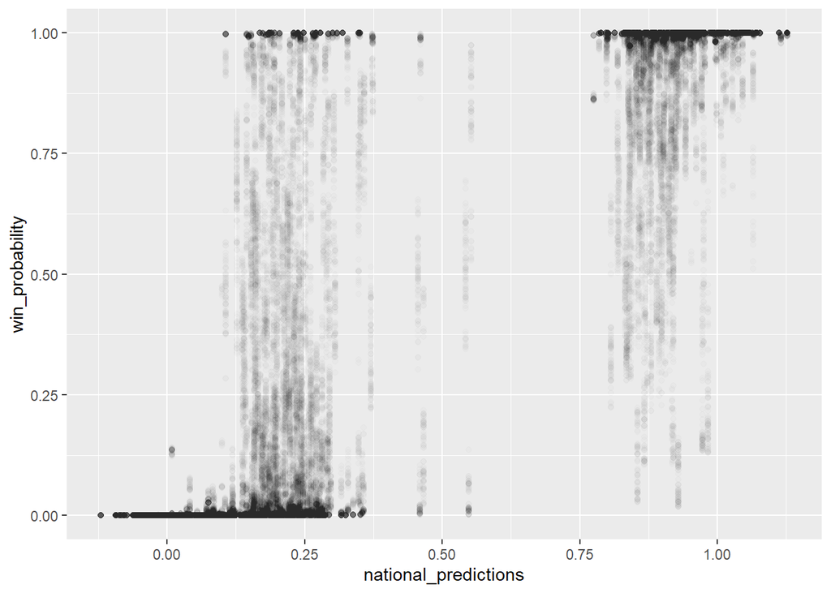

```r
national_predictions <- predict(train_model, test)
ggplot(data=test, aes(x=national_predictions, y=win_probability )) + geom_point(alpha = 0.01)
```

## Conclusion

This may help me discover what actually has us choosing the same congress people over and over again the next time.